# Investigation of PISA study 2012

## by Felix Deichsel

## Investigation Overview

The main goal is to elaborate, which influence parents have on the performance of their children in reading, mathematics and science. Further more, I want to know basic results of the PISA study like which countries performed best or whether there are differences in the performance of male and female students. Following parameters are consindered:

- Country of test
- The gender of the student
- Parents being at home
- Job situation of parents
- Level of Education of parents
- Additional lessons given by parents

## Dataset Overview

The final dataset, that is investigated, consists of 17 columns. Those are:

- 2 columns of datatype ordered category, that contain the highest education of mother and father)
- 5 columns of datatype float64 (4 score columns and one, that contains the number of lessons with a parent)
- 10 columns of datatype category (columns giving information about country, OECD status, whether parents are at home, job status and birth country)

## Distribution of the scores

For three test area math, reading and science the distribution seems to be very similar. Following observations can be made:

- The three distributions seem to be normal distributed
- The distributions have nearly the same mean, which is in the range of 481 to 486 points, and also the similiar standard deviation, which is in the range of 98-101 points. This means, that about 68.2% of the students scored between 380 and 580 points in each test area.
- Furthermore, the combined score from math, reading and science, is also normal distributed. The mean is 1452 points and the standard deviation is 285,12 points.

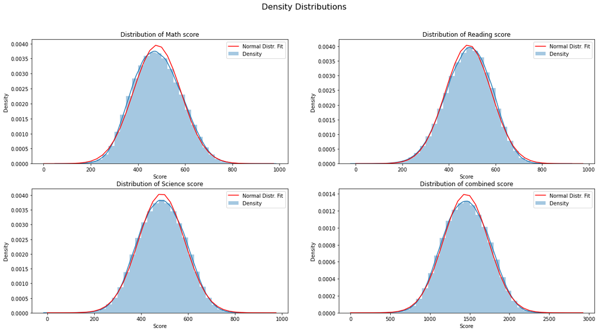

## Correlation of Scores

When investigating the pair-by-pair relationship between math scores, reading scores, science scores and combined scores, following insight can be found:

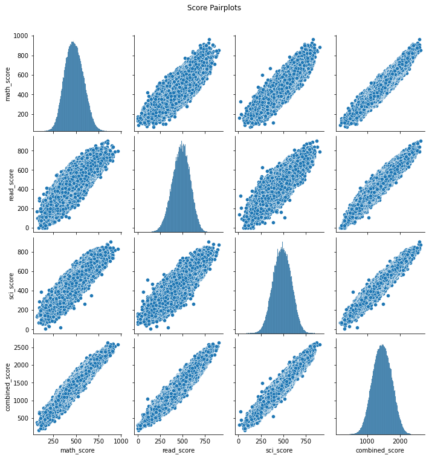

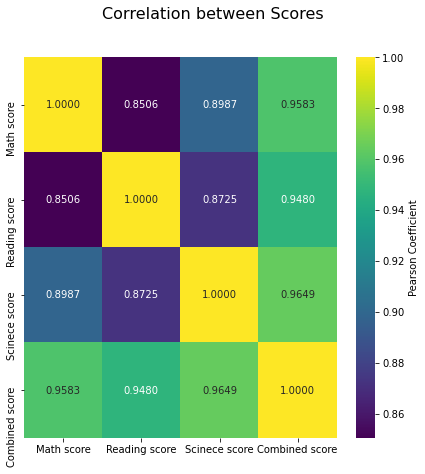

## Performance by country

The scores of students strongly depends on the country the test was taken. The highest average scores in each test area were achieved in China-Shanghai. Furthermore the front places are held by primarily asian countries like China-Shanghai, Singapore, Hong Kong-China, Chinese Taipei, Korea, Japan, Macao.

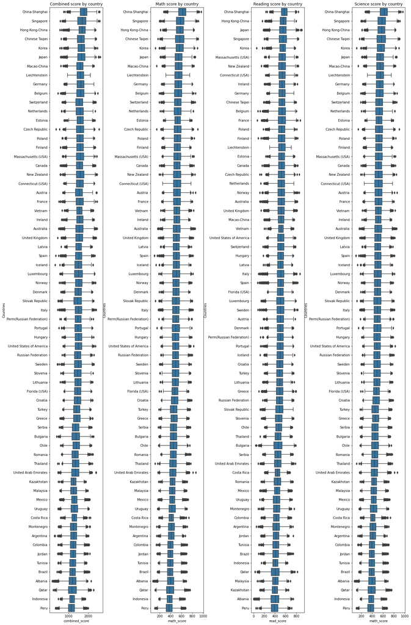

The countries, that took part, can also be divided in OECD and non OECD countries. The average combined score in OECD countries is about 1505 points, in Non-OECD countries only 1366 points. Also the spread is a larger: The standard deviation is about 294 points for Non-OECD countries and only 265 points for OECD countries.

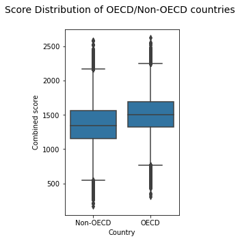

## Performance related to parents being at home

Concerning the variables, whether mother and/or father are at home or not, its seems, like students perform at their best, when both parents are at home and worst, when no parent is at home. There is a big difference between both parents being at home (score is about 1465 on average) versus both paretns not being at home (score is about 1186 on average). When only one parent is at home, students perform better, if that parent is their mother.

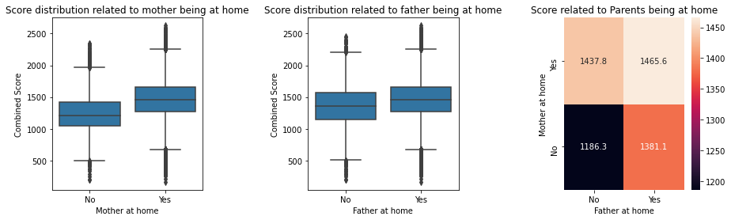

## Scores related to the job status

The investigation of the distribution of the parental job status gives following insights:

- Fathers work more often in full time, whereas mothers work more often part time or are engaged with other things, like household oe retirement
- Slightly more mothers are currently on job seach than fathers

The investigation of the score related to the parental job status gives following insights:

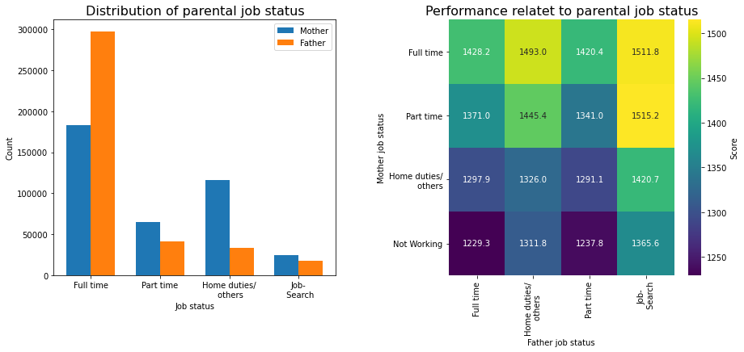

## Performance related to parental education level

- Looking at the distribution of parental education level we see, that the most frequent level is **5A**, followed by **3A** and **2**. Least frequent are **0** and **6**.
- Looking at the education level of parents, students perform better, when the combined education level of both parents is high. The best average performance is achieved, when both parents have education level **5A**.
- Noticeable is, that students perform exceptionally poorly, when one parent got level **6** and the other **0**.

[output not shown]

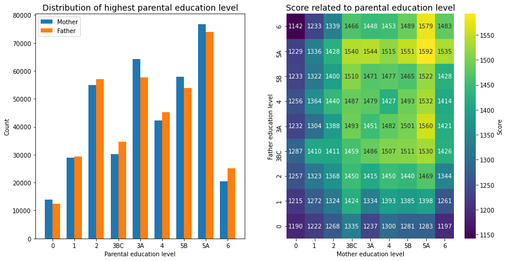

Also interesting is the fact, that the outperformance of female students compared to male students increases, the better both parents are educated. Overmore, a high education level of the mother boosts the performance of their daughters compared to their sons. The highest relative difference between female and male students can be found, when the mother got education level 6 and the father level 0. Maybe mothers are a role model for their daughter in those cases. Generally female students seem to profit more than male students, when their mother got education level 6.

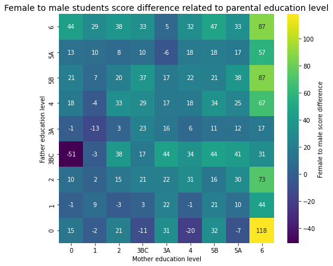

## Performance in dependence of additional lessons given by parents

Concerning the distribution of additional lessons given by parents, following observations can be made:

- Most students do not receive any additional lessons by their parents
- The distribution is strongly right skewed and non-symmetric. with a maximum of 125220 at 0 hours, and nearly no cases with more than 15 hours.

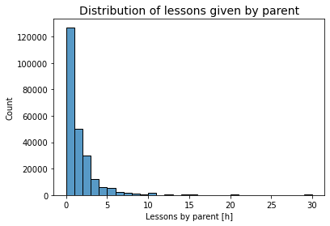

Concerning the relation between score and time spent for additional lessons given by parent, following insight can be made:

- Time spent with those lessons correlate negative with the combined score. In a certain way this is what one would expect, because only students, who need to get better receive extra lessons. Students perform on average 21.3 points worse per received lesson.
- Interestingly, for each lesson hour the score difference between female and male students increases. Males perform 23.24 points worse for each received lessons, females only 19.49 points. Maybe female students get more profit of given lessons given by a parent.

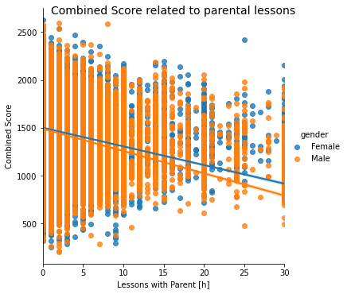

Looking at how many additional lessons students receive by their parents related to the education level of their parents , I find the following:

- The most time for additional lessons receive students of parents, that have education level 0, which is arount 1.5 hours.
- The shortest time for additional lessons receive students of parents, that have education level 3BC, which is arount 0.9 hours
- From education level 3BC starting to level 6, the time increases again up to 1.4 hour per week
- Generally, female students get more lesson time than male students

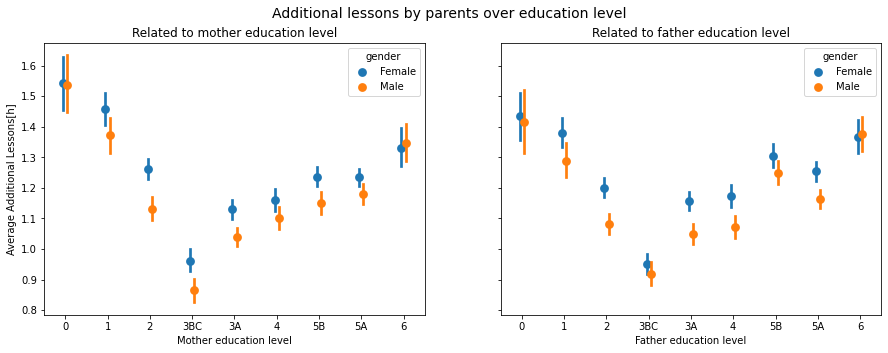